# ESM 204 - Assignment 3

Conner Smith and Russel Fager

5/2/2022

```r
knitr::opts_chunk$set(echo = TRUE, message = FALSE, warning = FALSE, options(scipen = 999))

library(tidyverse)
library(here)
library(janitor)
library(thematic)
library(scales)
library(equatiomatic)

thematic::thematic_rmd()
thematic::thematic_on()
```

## Overview

```r
# Read in the main data set

carbon <- read_csv(here("carbon.csv")) %>%
  clean_names() %>%
  select(-x1)
```

The Biden Administration’s “interim” value is $51 per metric ton of CO2. The electricity sector is the second largest source of greenhouse gas emissions in the U.S. (after transportation). In this analysis, we consider the distributional consequences of imposing a household electricity tax based on the SCC to address the climate change problem.

## **Analysis**

The dataset contains the following:

- Consumers can separated into two income groups: “high” and “low.”
- Price (in $) and quantity (in kWh) estimates of demand per month for the two groups.

This analysis will start with linear regressions (with an intercept) to estimate the demand curves for “high” and “low” income consumers under the following conditions:

- Initially, there is no tax on electricity consumption.
- The current electricity price (without any taxes) is $.10 per kWh.
- The marginal cost of producing a kWh of electricity is linear and has a price-intercept of 0.

### **1. MEC**

Assuming that one kWh of electricity emits 0.85 pounds of CO2 and that the interim SCC of $51/ton is accurate, this section calculates the MEC per kWh.

```r
# Create a longer dataset where income is a variable, not a column

carbon_long <- carbon %>%
  pivot_longer(cols = c(q_low_kwh, q_high_kwh),
               names_to = 'income_level',
               values_to = 'kwh') %>%
  mutate(income_level = case_when(income_level == 'q_low_kwh' ~ 'low',
                   income_level == 'q_high_kwh' ~ 'high'))

# Run a simple calculation to get the MEC

interim_price_ton <- 51

#2205 lbs in a metric ton. Divide by 0.85 to get kwh produced per ton

kwh_ton <- 2204.6/0.85

# Multiply by Biden price to get MEC/kWh (Basically, $51 is the price for 2594 kwh)
interim_price_kwh <- 51/kwh_ton
```

Based on this, the marginal externality cost per kWh of electricity is $0.0197.

### **2. Aggregations**

**Low income demand curve:**

```r
# Calculate aggregate demand curve for electricity

# First get lm estimates from data for both low and high
demand_low <- lm(price_cents ~ kwh, income_level=='low',
                 data = carbon_long)
extract_eq(model = demand_low, use_coefs = TRUE, coef_digits = 5)
```

$$\operatorname{\widehat{price\_cents}} = 23.37097 - 0.00011(\operatorname{kwh})$$

**High income demand curve:**

```r
demand_high <- lm(price_cents ~ kwh, income_level=='high',
                  data = carbon_long)
extract_eq(model = demand_high, use_coefs = TRUE, coef_digits = 5)
```

$$\operatorname{\widehat{price\_cents}} = 31.60686 - 0.00005(\operatorname{kwh})$$

```r
# Generalized demand model from sample code
demand <- function(p, model){
  q <- (p - model$coefficients[[1]])/model$coefficients[[2]]
  q <- ifelse(q<0,0,q)
  return(q)
}

# Generalized aggregate demand from code sample (gives sluightly different value than manual attempt)
demand_agg <- function(p){
  q <- demand(p, demand_low) + demand(p, demand_high)
  return(q)
}

#demand_agg(10)
#536,719.5 kWh consumed @ $0.10
```

Given these income-based demand curves, we can sum horizontally to get the aggregate demand curve. This does not follow a perfect line due to the kink at the top.

```r
# Make a vector and extract the lm
price = seq(0, 30, length.out = 100)

Qagg <- map(price, demand_agg) %>%
  unlist()

agg_df<- tibble(Qagg = Qagg, price = price)

# Note this is incorrect given the kink
#demand_agg_eq <- lm(price ~ Qagg, data = agg_df)
#extract_eq(model = demand_agg_eq, use_coefs = TRUE, coef_digits = 5)
```

*Note: this gives price in cents, not dollars*

Now we need to calculate the supply curve for electricity. We already know that the current price is $0.10/kWh. We also know the MC for electricity is linear with a 0 intercept.

```r
kwh_agg <- demand_agg(10)
#536,719.5 kWh consumed @ $0.10

supply_slope <- 10/kwh_agg

supply <- function(p){
  q <- p/supply_slope
  return(q)
}
```

Since we know the supply curve will pass through the aggregate demand curve at the level of demand for a price of $0.10/kwh, we can infer that the supply curve (or marginal cost per kWh of electricity) function is:

*P = 0.0000186Q*

*Note: this gives a price in cents, not dollars*

#### **Figure 1: Market for Electricity**

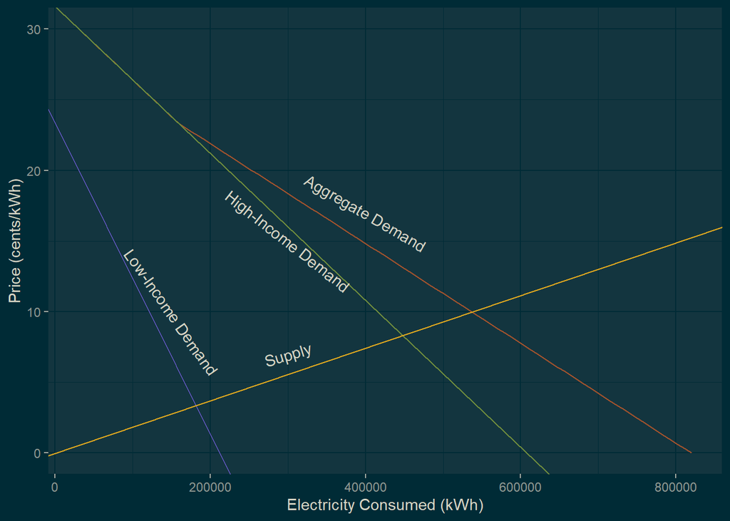

```r
# Visualize all fo the above curves

#First make a new df with the low and high income curves, as well as the supply curve

ggplot(agg_df, aes(Qagg, price)) +
  geom_line(color = "sienna") +
  annotate("text", x = 400000, y = 17,
           label = "Aggregate Demand", angle = -30) +
  geom_abline(color = "darkolivegreen4",
              intercept = demand_high$coefficients[1],
              slope= demand_high$coefficients[2]) +
  annotate("text", x = 300000, y = 15,
           label = "High-Income Demand", angle = -38) +
  geom_abline(color = "slateblue",
              intercept = demand_low$coefficients[1],
              slope= demand_low$coefficients[2]) +
  annotate("text", x = 150000, y = 10,
           label = "Low-Income Demand", angle = -55) +
  geom_abline(color = "goldenrod",
              intercept = 0,
              slope= supply_slope) +
  annotate("text", x = 300000, y = 7,
           label = "Supply", angle = 17) +
  labs(x = "Electricity Consumed (kWh)",
       y = "Price (cents/kWh)")
```

From these curves, we can calculate consumer and producer surplus as well as environmental cost.

```r
# CS needs Y intercept --> at 0 kWh, price would be $0.305

# Note the conversion back to dollars
cs_baseline <- 0.5*kwh_agg*(0.305 - 0.10)
# $55,013.74

# PS easy, just go up to 10 and out to the kwh
ps_baseline <- 0.5*kwh_agg*0.10
# $26,835.97

# cost is rectangle
env_cost_baseline <- interim_price_kwh*kwh_agg
# $10,553.75
```

- Consumer Benefit = $55014
- Producer Benefit = $26836
- Environmental Cost = $10554

*Note these benefits and costs are in dollars, not cents*

### **3. Consumer Benefit**

To get the surplus differential between income groups, we use the current price and calculate the amount each group will consume at this level.

```r
# low income demand
# demand(10, demand_low)
# Low income gets 121,344
#demand_low$coefficients[1] --- intercept is 23.37

cs_low <- 0.5*(.2337 - .10)*demand(10, demand_low)
# Note: this is negative (-$2441) if we apply full env. cost

#demand(10, demand_low)
#High gets 415,376
#demand_high$coefficients[1] --- intercept is 31.61
cs_high <- 0.5*(.3161-.10)*demand(10, demand_high)
# $44,881.3 CS for high income assuming no EC
```

This indicates clear disparity where consumer surplus for high income consumers is much higher than that for low income consumers. The difference is as follows:

- Low-income CS: $8112
- High-income CS: $44881

### **4. Optimal Tax**

```r
# Trying taking tax straight from AD (Downward shift), account for this by subtracting the tax amount from the y intercept for each low and high income.

tax_cents <- 1.97
# Note this is in cents, this is what we subtract from the y intercept

demand_tax <- function(p, model){
  q <- (p - (model$coefficients[[1]]-1.97))/model$coefficients[[2]]
  q <- ifelse(q<0,0,q)
  return(q)
} # note, this is the same function but lowering the intercept for each


demand_agg_tax <- function(p){
  q <- demand_tax(p, demand_low) + demand_tax(p, demand_high)
  return(q)
}

#Now need to calculate when AD equals the supply curve, use the uniroot function setting AD and supply equal

#uniroot(function(p)
  #demand_agg_tax(p) - supply(p),
  #interval = c(0,20))

# This gives a price of $9.32

p_new <- 9.32

# At this price, Q will be: 500,213

q_new <- demand_agg_tax(p_new)
```

Now that we have the new equilibrium price and quantity, we can factor those in to get updates on all other aspects of this problem.

```r
demand_change <- kwh_agg - q_new
# A. Reduction in kwh consumed of 36,506.26

price_change <- 10 - p_new

# B. The cost of electricity goes down by $0.68

# C. High income welfare (suplus minus tax) decreases, factor in tax dues also
#subtract tax amount from initial intercept, be careful of cents to dollars.
demand_high_tax <- demand_tax(p_new, demand_high)

cs_high_tax <- (0.5 * (demand_high$coefficients[1]-tax_cents-p_new) * demand_high_tax)/100

#welfare is CS - tax expense
welfare_high_tax <- cs_high_tax - (demand_high_tax * 0.0197)

# "Welfare" for high income initially is same as CS since there is no externality/tax for them.
welfare_high_change <- cs_high - welfare_high_tax
# High income welfare drops by $12,893

# D. Low income welfare, NEED TO DEDUCT DAMAGE AND TAX, as well as getting initial welfare (which is negative)

welfare_low_baseline <- cs_low - env_cost_baseline

demand_low_tax <- demand_tax(p_new, demand_low)
#Below is the total env cost at the new level of consumption
env_cost_tax <- interim_price_kwh * q_new

cs_low_tax <- (0.5 * (demand_low$coefficients[1]-tax_cents-p_new) * demand_low_tax)/100

welfare_low_tax <- cs_low_tax - (demand_low_tax * 0.0197) - env_cost_tax

welfare_low_change <- welfare_low_baseline - welfare_low_tax


#E. PS decreases
ps_tax <- 0.5*q_new*0.0932
ps_change <- ps_baseline - ps_tax
#$3526 decrease

#F. ENV damage decreases

damage_change <- env_cost_baseline - env_cost_tax
#Damage goes down by $717.8 (small change)

#G. Tax revenue

tax_revenue <- interim_price_kwh*q_new
# $9,835 tax revenue (this is exactly the same as the env cost)
```

**A:** The amount of electricity produced/consumed *decreases* by 36506kWh. The new total consumption is 500213 kWh.

**C:** The welfare of high-income *decreases* by $12899. This includes the cost of taxes paid by these consumers.

**D:** The welfare of low-income consumers *decreases* by $2931. *Note: welfare was already negative for low-income consumers if we assume they bear the full environmental cost associated with electricity production.*

**E:** The producer surplus *decreases* by $ 3526.

**F:** The environmental damage *decreases* by $718.

**G:** The tax revenue generated is $9836. *Note: this is equal to the total environmental cost.*

### **5. Redistribution**

```r
# Calculating different prices

# If price/ton is $75 --- 75/(2204.6/0.85) --- $0.0289/kWh
# If price/ton is $100 --- 100/(2204.6/0.85)--- $0.0386.kWh
# If price/ton is $125 --- 125/(2204.6/0.85) --- $0.0482/kWh
# If price/ton is $150 --- 150/(2204.6/0.85) --- $0.0578/kWh

tax_75 <- 2.89
tax_100 <- 3.86
tax_125 <- 4.82
tax_150 <- 5.78

# Should create a vector of this
scc_list <- c(2.89, 3.86, 4.82, 5.78)

# pre-tax consumption

low_share <- demand(10, demand_low)/kwh_agg
#22.61%
high_share <- demand(10, demand_high)/kwh_agg
#77.39%

# @ $51 (the original SCC):

low_redist_51 <- low_share*tax_revenue
#Get $2224 back
low_welfare_51 <- low_redist_51 + welfare_low_tax
#New welfare is equal to initial welfare --- (-$2422)

high_redist_51 <- high_share*tax_revenue
# Get $7612 back
high_welfare_51 <- high_redist_51 + welfare_high_tax
```

The following are the high-income welfare, low-income welfare, and producer surplus at five SCC levels:

```r
###### Welfare @ $75


#First get AD @ $75
demand_scc <- function(p, model, scc){
  q <- (p - (model$coefficients[[1]] - scc_list[scc]))/model$coefficients[[2]]
  q <- ifelse(q<0,0,q)
  return(q)
}


demand_agg_75 <- function(p){
  q <- demand_scc(p, demand_low, 1) + demand_scc(p, demand_high, 1)
  return(q)
}


p_75 <- uniroot(function(p)
  demand_agg_75(p) - supply(p),
  interval = c(0,20))
#Gives new P of 9.002

demand_75 <- demand_agg_75(p_75$root)

revenue_damage_75 <- demand_75*.0289

#Low Income @ $75
demand_low_75 <- demand_scc(p_75$root, demand_low, 1)
cs_low_75 <- (0.5*demand_low_75*(demand_low$coefficients[1]-tax_75-p_75$root))/100
# Welfare is CS - tax + money back
welfare_low_75 <- cs_low_75 - (demand_low_75 * .0289) - revenue_damage_75 + low_share*revenue_damage_75


# High Income @$75
demand_high_75 <- demand_scc(p_75$root, demand_high, 1)
cs_high_75 <- (0.5*demand_high_75*(demand_high$coefficients[1]-tax_75-p_75$root))/100

welfare_high_75 <- cs_high_75 - (demand_high_75*0.0289) + high_share*revenue_damage_75
# Producer @ $75
ps_75 <- 0.5*demand_75*(p_75$root/100)
```

```r
###### Welfare @ $100

#First get AD @ $75

demand_agg_100 <- function(p){
  q <- demand_scc(p, demand_low, 2) + demand_scc(p, demand_high, 2)
  return(q)
}

p_100 <- uniroot(function(p)
  demand_agg_100(p) - supply(p),
  interval = c(0,20))
#Gives new P of 8.667

demand_100 <- demand_agg_100(p_100$root)

revenue_damage_100 <- demand_100*.0386

#Low Income @ $100
demand_low_100 <- demand_scc(p_100$root, demand_low, 2)
cs_low_100 <- (0.5*demand_low_100*(demand_low$coefficients[1]-tax_100-p_100$root))/100
welfare_low_100 <- cs_low_100 - (demand_low_100*0.0386) - revenue_damage_100 + low_share*revenue_damage_100


# High Income @$100
demand_high_100 <- demand_scc(p_100$root, demand_high, 2)
cs_high_100 <- (0.5*demand_high_100*(demand_high$coefficients[1]-tax_100-p_100$root))/100
welfare_high_100 <- cs_high_100 - (demand_high_100*0.0386) + high_share*revenue_damage_100

# Producer @ $100
ps_100 <- 0.5*demand_100*(p_100$root/100)
```

```r
###### Welfare @ $125

demand_agg_125 <- function(p){
  q <- demand_scc(p, demand_low, 3) + demand_scc(p, demand_high, 3)
  return(q)
}

p_125 <- uniroot(function(p)
  demand_agg_125(p) - supply(p),
  interval = c(0,20))
#Gives new P of 8.336

demand_125 <- demand_agg_125(p_125$root)
revenue_damage_125 <- demand_125*.0482

#Low Income @ $125
demand_low_125 <- demand_scc(p_125$root, demand_low, 3)
cs_low_125 <- (0.5*demand_low_125*(demand_low$coefficients[1]-tax_125-p_125$root))/100
welfare_low_125 <- cs_low_125 - (demand_low_125*0.0482) - revenue_damage_125 + low_share*revenue_damage_125


# High Income @$125
demand_high_125 <- demand_scc(p_125$root, demand_high, 3)
cs_high_125 <- (0.5*demand_high_125*(demand_high$coefficients[1]-tax_125-p_125$root))/100
welfare_high_125 <- cs_high_125 - (demand_high_125*0.0482) + high_share*revenue_damage_125

# Producer @ $125
ps_125 <- 0.5*demand_125*(p_125$root/100)
```

```r
###### Welfare @ $150

demand_agg_150 <- function(p){
  q <- demand_scc(p, demand_low, 4) + demand_scc(p, demand_high, 4)
  return(q)
}

p_150 <- uniroot(function(p)
  demand_agg_150(p) - supply(p),
  interval = c(0,20))
# New P of $8.0045, but actual price paid is P + tax

demand_150 <- demand_agg_150(p_150$root)
revenue_damage_150 <- demand_150*.0578

# Low income @$150
demand_low_150 <- demand_scc(p_150$root, demand_low, 4)
cs_low_150 <- (0.5*demand_low_150*(demand_low$coefficients[1]-tax_150-p_150$root))/100
welfare_low_150 <- cs_low_150 - (demand_low_150*0.0578) - revenue_damage_150 + low_share*revenue_damage_150


# High Income @$150
demand_high_150 <- demand_scc(p_150$root, demand_high, 4)
cs_high_150 <- (0.5*demand_high_150*(demand_high$coefficients[1]-tax_150-p_150$root))/100
welfare_high_150 <- cs_high_150 - (demand_high_150*0.0578) + high_share*revenue_damage_150

# Producer @ $100
ps_150 <- 0.5*demand_150*(p_150$root/100)
```

**A: High-income welfare**

- SCC of 51 USD/ton: $39594.
- SCC of 75 USD/ton: $37213.
- SCC of 100 USD/ton: $34729.
- SCC of 125 USD/ton: $32316.
- SCC of 150 USD/ton: $29946.

*Note: High income welfare decreases with increasing SCC levels assuming taxes are deducted from consumer surplus and the redistribution is added based on their pre-tax share of electricity consumption* (77%).

**B: Low-income welfare**

- SCC of 51 USD/ton: $-3149.
- SCC of 75 USD/ton: $-7838.
- SCC of 100 USD/ton: $-12360.
- SCC of 125 USD/ton: $-16423.
- SCC of 150 USD/ton: $-20076.

*Note: Low income welfare decreases with increasing SCC levels assuming taxes are deducted from consumer surplus, the entire environmental cost is deducted, and the redistribution is added based on their pre-tax share of electricity consumption* (23%).

**C: Producer Welfare**

- SCC of 51 USD/ton: $23310.
- SCC of 75 USD/ton: $21748.
- SCC of 100 USD/ton: $20160.
- SCC of 125 USD/ton: $18648.
- SCC of 150 USD/ton: $17195.

*Note: Producer surplus decreases as SCC increases due to declining quantities consumed.*

### **6. Solar PV**

What happens when the high-income demand curve is reduced by half?

```r
# New high-income demand

demand_high_solar <- function(p){
  q <- (p - (demand_high$coefficients[[1]]-1.97)/2)/demand_high$coefficients[[2]]
  q <- ifelse(q<0,0,q)
  return(q)
}

#Low income demand, again
demand_low_solar <- function(p){
  q <- (p - (demand_low$coefficients[[1]]-1.97))/demand_low$coefficients[[2]]
  q <- ifelse(q<0,0,q)
  return(q)
}

demand_agg_solar <- function(p){
  q <- demand_high_solar(p) + demand_low_solar(p)
  return(q)
}

p_solar <- uniroot(function(p)
  demand_agg_solar(p) - supply(p),
        interval = c(0,20))

price_solar <- p_solar$root
# New price is 5.845

demand_solar <- demand_agg_solar(price_solar)
#313691 is new demand

env_cost_solar <- demand_solar*0.0197

# Need to find point on original AD where Q  is equal to solar equation Q

#demand_agg(17.88)
#The tax is the difference between the point on the AD curve and on the supply curve
#17.88-5.845
tax_final <- 12.035
```

**A:** Total electricity consumption with solar is 313692 kWh.

**B:** Total environmental cost is $6180.

**C:** The tax to make the environmental damage associated with the 51 USD SCC and no solar equal to the environmental damage with solar would be $0.12035.

*Note: this is an exorbitantly high tax and shows the benefit of reducing the carbon intensity of energy generation sources.*